# Visualizing data

Nic Rivers

7/26/2019

## Visualizing data

In this class, we will learn how to make plots from data using the `ggplot()` function contained in the `tidyverse` library. We will do two sets of excercises, first with data on refugee flows from the UN, and second with data on earnings from the Canadian labour force survey.

`ggplot2` is an extremely flexible language for creating figures. We will not be able to cover the full flexibility of the system in this class. For additional help, see R4DS, this [tutorial](http://r-statistics.co/Complete-Ggplot2-Tutorial-Part1-With-R-Code.html), or take a look at the code used for a [figure](http://r-statistics.co/Top50-Ggplot2-Visualizations-MasterList-R-Code.html) you’d like to recreate.

## Obtaining data

The UN provides lots of data, including data on [worldwide refugee flows](http://data.un.org/Data.aspx?q=refugees&d=UNHCR&f=indID:Type-Ref&c=0,1,2,3,4,5,6&s=yr:desc,asyEngName:asc,oriEngName:asc&v=1). Click the download link and save the .csv file to the data directory in the /class3/ folder. Now create a script and load the tidyverse package, and read in the data.

```r
library(tidyverse)
dat <- read_csv("data/UNdata_Export_20190722_185911178.zip")
```

The names are a mess. Let’s clean them up (remove spaces and special symbols) using the `clean_names()` function in the `janitor` package. You’ll need to install this package if it’s your first time using it: `install.packages("janitor")`.

```r
library(janitor)
dat <- dat %>%
  clean_names()
# See the names of the variables now:
dat
```

```
## # A tibble: 96,064 x 7
##    country_or_terr~ country_or_terr~  year refugees_sup_sup
##    <chr>            <chr>            <dbl>            <dbl>
##  1 Afghanistan      Iraq              2016                1
##  2 Afghanistan      Islamic Rep. of~  2016               33
##  3 Afghanistan      Pakistan          2016            59737
##  4 Albania          China             2016               11
##  5 Albania          Dem. Rep. of th~  2016                3
##  6 Albania          Egypt             2016                3
##  7 Albania          Iraq              2016               23
##  8 Albania          Islamic Rep. of~  2016               17
##  9 Albania          Montenegro        2016                2
## 10 Albania          Peru              2016                1
## # ... with 96,054 more rows, and 3 more variables:
## #   refugees_assisted_by_unhcr <dbl>,
## #   total_refugees_and_people_in_refugee_like_situations_sup_sup <dbl>,
## #   total_refugees_and_people_in_refugee_like_situations_assisted_by_unhcr <dbl>
```

```r
names(dat)
```

```
## [1] "country_or_territory_of_asylum_or_residence"
## [2] "country_or_territory_of_origin"
## [3] "year"
## [4] "refugees_sup_sup"
## [5] "refugees_assisted_by_unhcr"
## [6] "total_refugees_and_people_in_refugee_like_situations_sup_sup"
## [7] "total_refugees_and_people_in_refugee_like_situations_assisted_by_unhcr"
```

Let’s filter the data to just look at refugees that are in Canada that originated in Afghanistan Give this smaller data set a new name. See if you can do this yourself before looking below.

```r
new_data <- dat %>%
  filter(country_or_territory_of_asylum_or_residence == "Canada",
         country_or_territory_of_origin == "Afghanistan") %>%
  select(year, refugees=refugees_sup_sup)
new_data
```

```
## # A tibble: 23 x 2
##     year refugees
##    <dbl>    <dbl>
##  1  2016     3177
##  2  2015     2890
##  3  2014     2704
##  4  2013     2700
##  5  2012     2609
##  6  2011     2659
##  7  2010     2727
##  8  2009     3015
##  9  2008     3147
## 10  2007     3470
## # ... with 13 more rows
```

## A first plot: Refugees from Afghanistan to Canada

So we have a data set with refugee flows from Afghanistan to Canada over a number of years. We will plot the data set using `ggplot2`, a function for plotting that is part of the `tidyverse` package that we have already started using. The syntax for `ggplot2` takes a bit of getting used to, but it is very flexible and allows for building up complicated figures, one “layer” at a time. The basic structure of a ggplot function is as follows: `ggplot(data = [data_name], aes(x=[x_variable], y=[y_variable], colour=[colour_variable], ...)) + geom_[name]()` (you fill in the parts in `[]`). This is a bit abstract, so we will see what happens when we plot with our real data set:

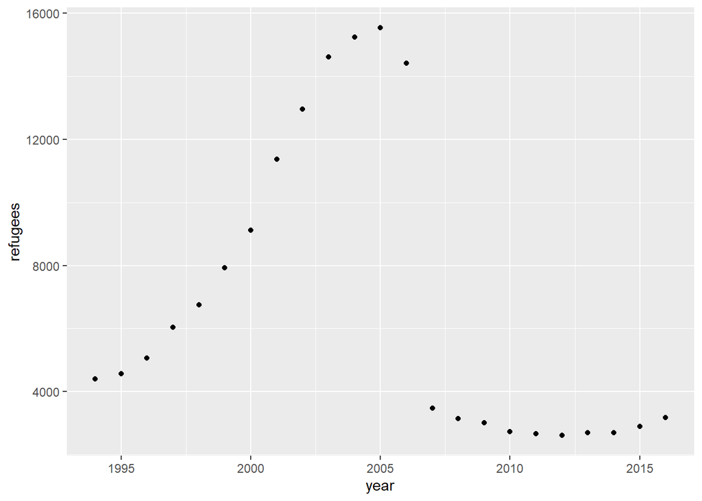

```r
# First, tell ggplot what data to use
ggplot(data=new_data,
       # Now tell it the "aesthetics".  Here I just tell it what variables to plot on the x and y axes.
       aes(x=year, y=refugees)) +
  # Now tell it what to actually plot.  We tell it to plot points.
  geom_point()
```

## Geoms

In the function above, we tell `ggplot` to plot our `new_data` data set. We tell it what variable to put on the x axis and the y axis. These are the “aesthetics” of the graph. Each “aesthetic” relates some variable in our data set to some feature of the graph. Then we can tell it what to plot, given the aesthetics: we tell it to plot points (`geom_point`). It is possible to add “layers” the graph. For example, perhaps we want to plot points connected by lines. In that case, we could add a `geom_line()` to the function:

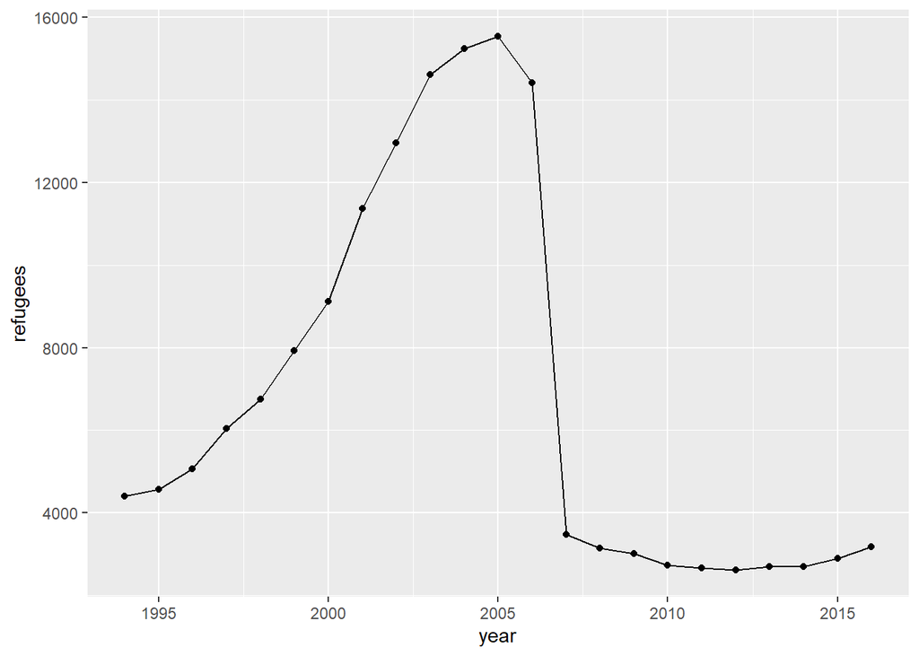

```r
# First, tell ggplot what data to use
ggplot(data=new_data,
       # Now tell it the "aesthetics".  Here I just tell it what variables to plot on the x and y axes.
       aes(x=year, y=refugees)) +
  # Now tell it what to actually plot.  We tell it to plot points.
  geom_point() +
  geom_line()
```

There are lots of different “geoms” available in ggplot2. You can find these [here](https://ggplot2.tidyverse.org/reference/). For example, we can add a “smoothing” geom to our plot (given the big discontinuity in 2007, it doesn’t really make sense to smooth this plot, so this is an illustration only):

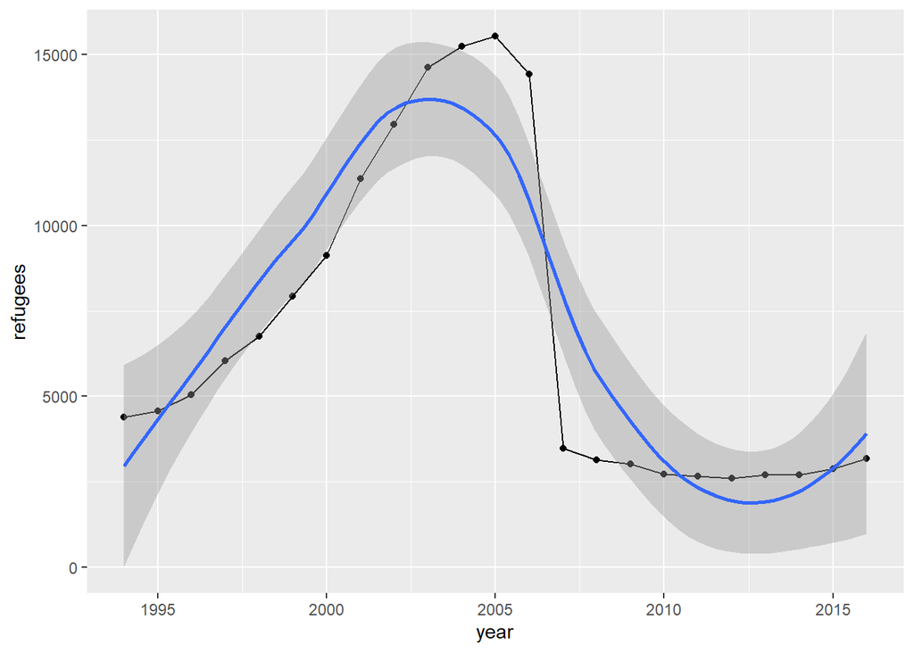

```r
ggplot(data=new_data,
       aes(x=year, y=refugees)) +
  geom_point() +
  geom_line() +
  geom_smooth()
```

To illustrate the usefulness of `ggplot2`, let’s ammend our data set a little, so that we include data on refugee flows to Canada from several countries:

```r
new_data_3 <- dat %>%
  filter(country_or_territory_of_asylum_or_residence == "Canada",
         country_or_territory_of_origin %in% c("Afghanistan","Syrian Arab Rep.","Lebanon")) %>%
  select(year, origin_country=country_or_territory_of_origin,refugees=refugees_sup_sup)
new_data_3
```

```
## # A tibble: 69 x 3
##     year origin_country   refugees
##    <dbl> <chr>               <dbl>
##  1  2016 Afghanistan          3177
##  2  2016 Lebanon               741
##  3  2016 Syrian Arab Rep.     2757
##  4  2015 Afghanistan          2890
##  5  2015 Lebanon               867
##  6  2015 Syrian Arab Rep.     1513
##  7  2014 Afghanistan          2704
##  8  2014 Lebanon              1024
##  9  2014 Syrian Arab Rep.      705
## 10  2013 Afghanistan          2700
## # ... with 59 more rows
```

## Aesthetics

We now have a data set with three variables – year, the country of origin, and the number of refugees. We can assign the variable origin country to another `aesthetic` in our plot: for example, we can give each country a different colour:

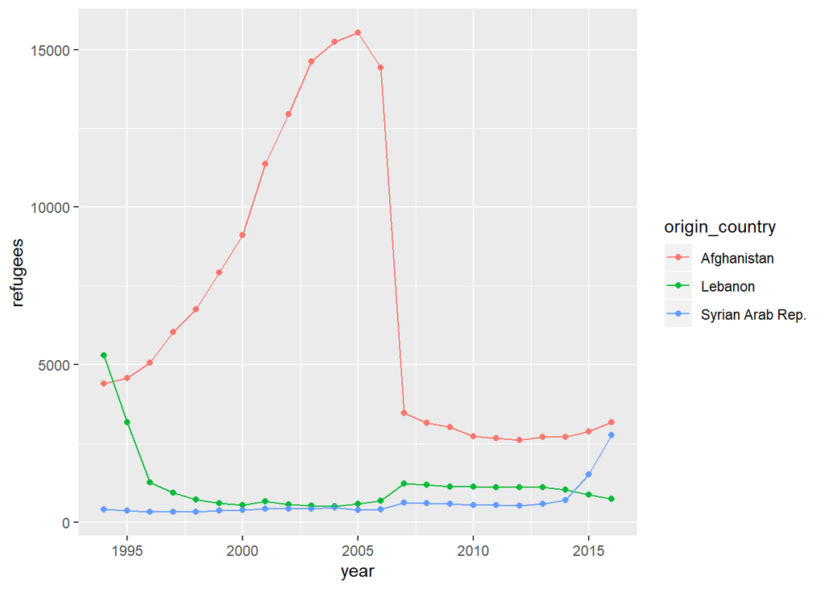

```r
ggplot(data=new_data_3,
       aes(x=year, y=refugees, colour=origin_country)) +
  geom_point() +
  geom_line()
```

We can assign a number of different aesthetics to variables. For example, we can assign the linetype to a variable, or the size of lines and points to a variable, or even the opacity of lines. We can also set the aesthetics individually for each geom. For example, this example sets the size and “alpha” (opacity) of points as a function of the number of refugees, and the colour and type of lines as a function of the country of origin.

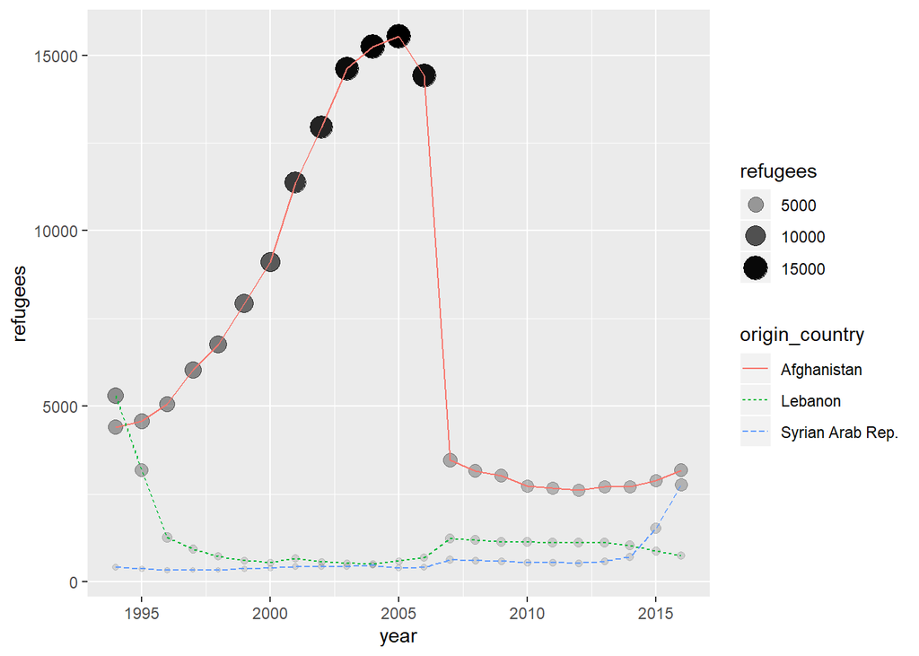

```r
ggplot(data=new_data_3,
       aes(x=year, y=refugees)) +
  # Now tell it what to actually plot.  We tell it to plot points.
  geom_point(aes(size=refugees, alpha=refugees)) +
  geom_line(aes(colour=origin_country, linetype=origin_country))
```

We can also change plot features such that the plot features are not directly linked to the data frame. For example, we could set the colours of the lines manually, rather than setting them according to a variable in the data frame. To do this, we set the colours outside of the aesthetics function:

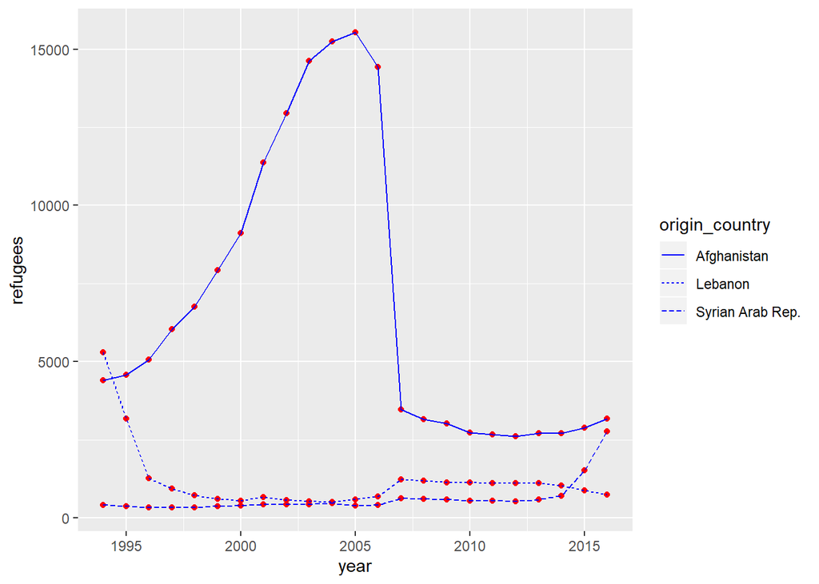

```r
ggplot(data=new_data_3,
       aes(x=year, y=refugees, linetype=origin_country)) +
  # Notice how I have specified the colour *outside* of the aes() brackets, and that it is not linked to a variable?  See the result below.
  geom_point(colour="red") +
  geom_line(colour="blue")
```

## Labels and themes

Now that we have a basic figure, we will start to customize it. We begin by adding some labels using the `labs()` function. We can set the title, subtitle, caption, x, and y labels:

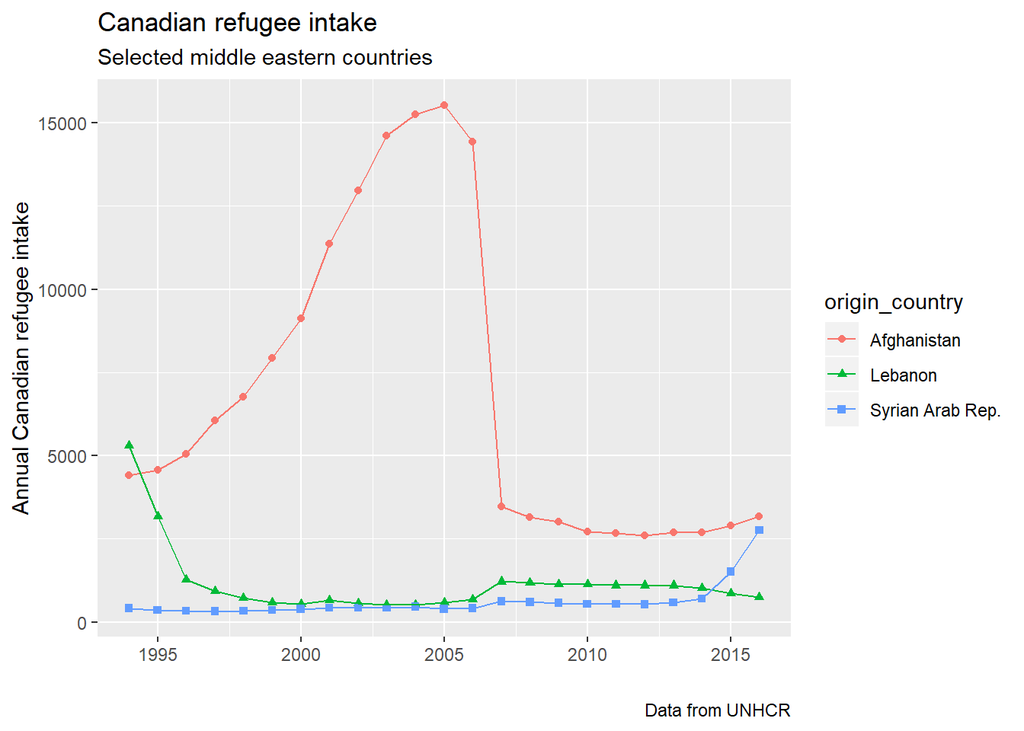

```r
ggplot(data=new_data_3,
       aes(x=year, y=refugees, colour=origin_country, shape=origin_country)) +
  geom_point() +
  geom_line() +
  labs(title="Canadian refugee intake",
       subtitle="Selected middle eastern countries",
       caption="Data from UNHCR",
       x="",
       y="Annual Canadian refugee intake")
```

We can also change the “theme” of the graph using one of a number of pre-defined themes. The base theme has a grey background and white gridlines, whereas `theme_light` has a white background and grey gridlines. You can find a number of pre-defined themes [here](https://ggplot2.tidyverse.org/reference/ggtheme.html) and there are packages that you can install that provide additional themes (`ggthemes` is one such package).

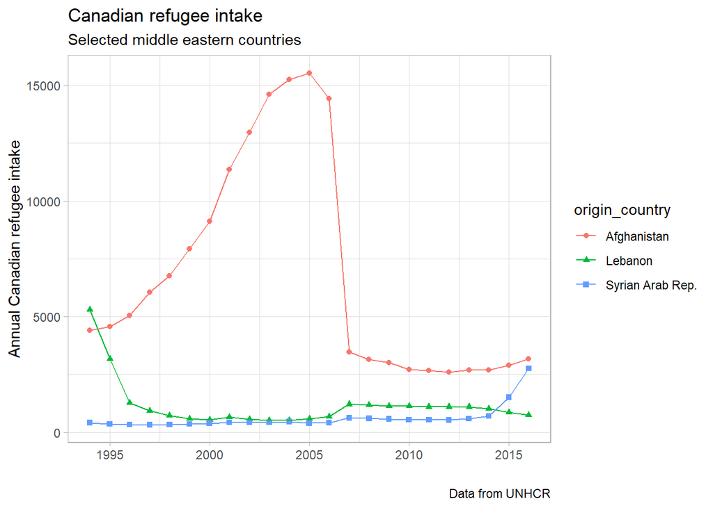

```r
ggplot(data=new_data_3,
       aes(x=year, y=refugees, colour=origin_country, shape=origin_country)) +
  geom_point() +
  geom_line() +
  labs(title="Canadian refugee intake",
       subtitle="Selected middle eastern countries",
       caption="Data from UNHCR",
       x="",
       y="Annual Canadian refugee intake") +
  theme_light()
```

## Annotations

Sometimes it’s useful to annotate directly within a figure, to highlight a point in the figure, or a particular trend. For example, we may want to include a vertical line indicating the transition to between the Liberal and Conservative governments in 2006, or some text to point to the large fall in Afghani refugees in 2007. Vertical lines can be added with a `geom_vline()` function (horizonal lines use `geom_hline()`), and annotations can be added with the `annotate()` function:

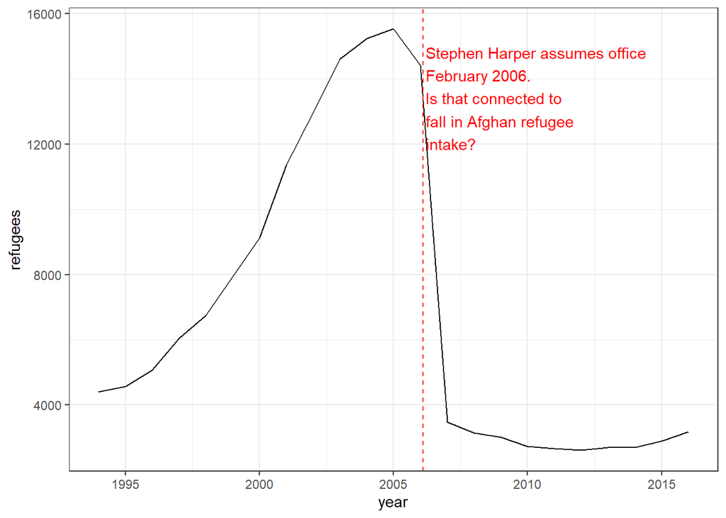

```r
ggplot(new_data,
       aes(x=year, y=refugees)) +
  geom_line() +
  geom_vline(xintercept = 2006.1, colour="red", linetype="dashed") +
  theme_bw() +
  annotate(geom="text",
           # Indicate where in the figure the annotation should go
           x=2006.2, y=15000,
           # Use "\n" for a new line (return) in annotation
           label="Stephen Harper assumes office\nFebruary 2006.\nIs that connected to\nfall in Afghan refugee\nintake?",
           colour="red",
           hjust=0,
           vjust=1)
```

## Facetting

`ggplot2` allows *facetting*: this means that we can create multiple graphs in one `ggplot()` call. For example, perhaps we would like to have multiple graphs, with each graph showing refugee intake to Canada from a single country. We can use facets for this:

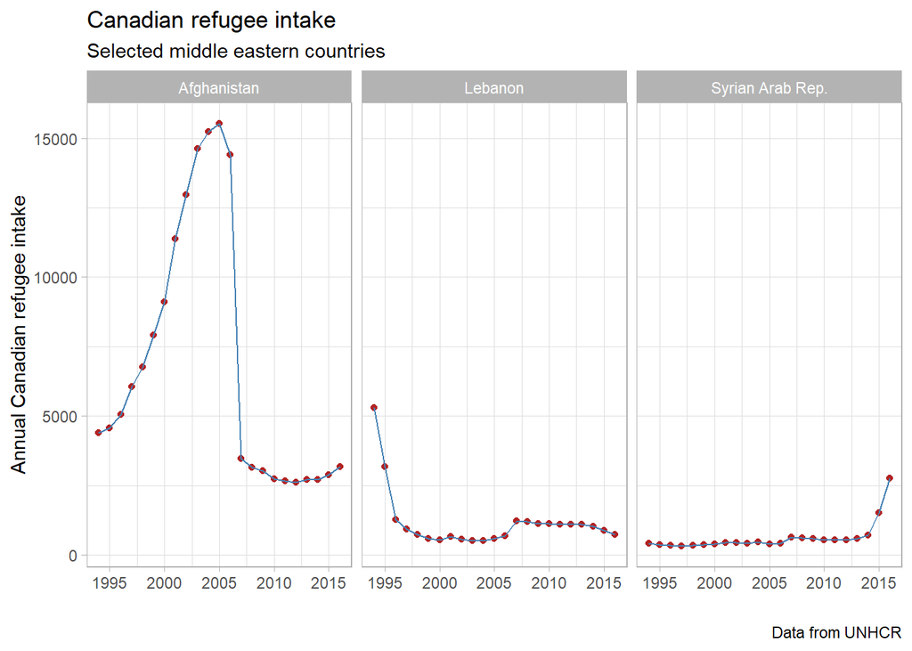

```r
ggplot(data=new_data_3,
       aes(x=year, y=refugees)) +
  # Tell ggplot to make a new "facet" for each origin_country
  facet_wrap(~origin_country) +
  geom_point(colour="firebrick") +
  geom_line(colour="steelblue") +
  labs(title="Canadian refugee intake",
       subtitle="Selected middle eastern countries",
       caption="Data from UNHCR",
       x="",
       y="Annual Canadian refugee intake") +
  theme_light()
```

You can set the scales in each of the individual facets so that they are all the same (the default; this makes it easy to compmare across facets) or so that they are all freely set (this makes it easy to see the trends in each facet). For example, this sets the y axis scale in each facet separately:

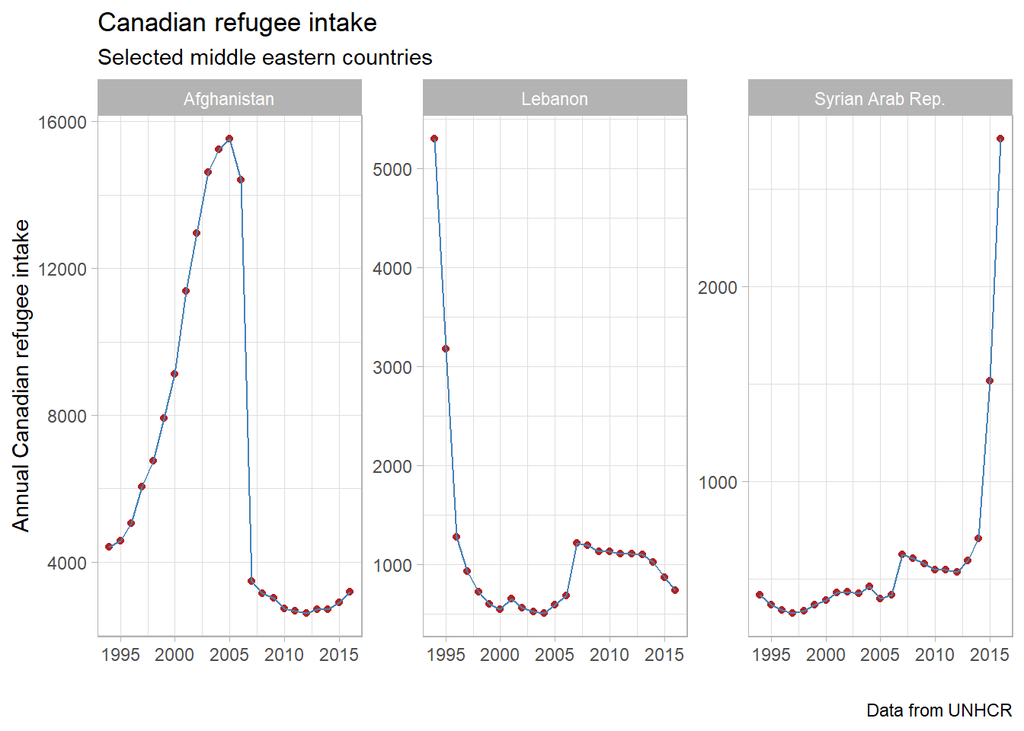

```r
ggplot(data=new_data_3,
       aes(x=year, y=refugees)) +
  # Tell ggplot to make a new "facet" for each origin_country
  facet_wrap(~origin_country, scales = "free_y") +
  geom_point(colour="firebrick") +
  geom_line(colour="steelblue") +
  labs(title="Canadian refugee intake",
       subtitle="Selected middle eastern countries",
       caption="Data from UNHCR",
       x="",
       y="Annual Canadian refugee intake") +
  theme_light()
```

## Scales

`ggplot` automatically chooses scales for your graph, but it is possible to set these manually as well. The “scales” in your plot include not only the x and y scales, but also any of the other aesthetics you have set to variables in your data set (colour, size, linetype, etc.). By setting scales, we can, for example, set custom tick marks on the x-axis, or choose a set of custom colours for the different lines in the plot. For example, we may want to format the y axis scale so it is more readable (we do this using `comma_format` in the `scales` library – note how we load that first), by putting a comma between thousands, and by choosing particular values of y for the gridlines:

```r
library(scales)
```

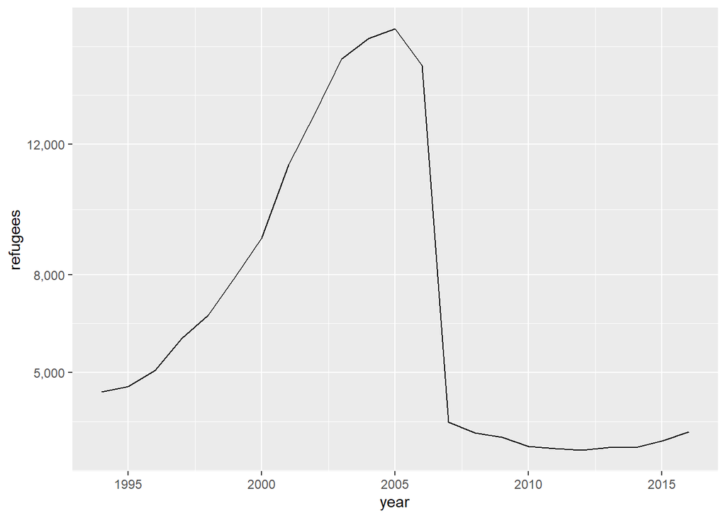

```r
ggplot(data=new_data,
       aes(x=year, y=refugees)) +
  geom_line() +
  scale_y_continuous(labels=comma_format(),
                     breaks=c(0,5000,8000,12000))
```

Setting the scale for an aesthetic other than x or y is similar. For example, we can override the default colours, and set a new title for the colour scale (see a list of colours and other aesthetics in R [here](https://ggplot2.tidyverse.org/articles/ggplot2-specs.html) or by typics `colours()` in the console):

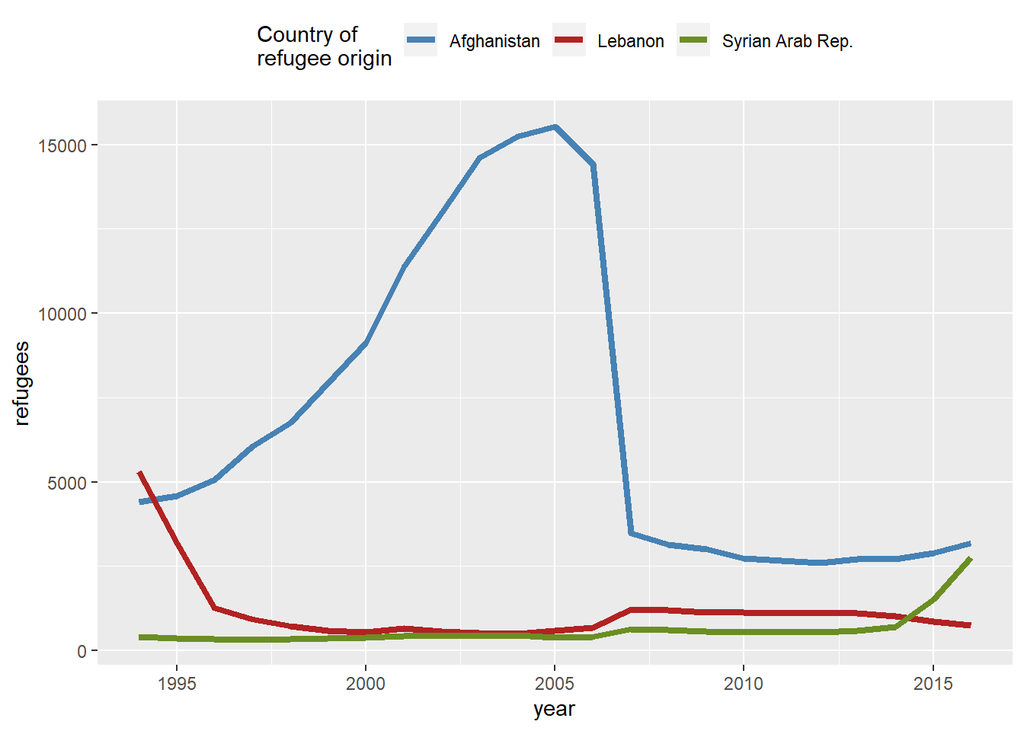

```r
ggplot(data=new_data_3,
       aes(x=year, y=refugees, colour=origin_country)) +
  geom_line(size=1.5) +
  scale_colour_manual(name="Country of\nrefugee origin",values = c("steelblue","firebrick","olivedrab")) +
  # Put the legend at the top
  theme(legend.position = "top")
```

Using the things we’ve learned above (plus a couple more), we can now make a finished plot:

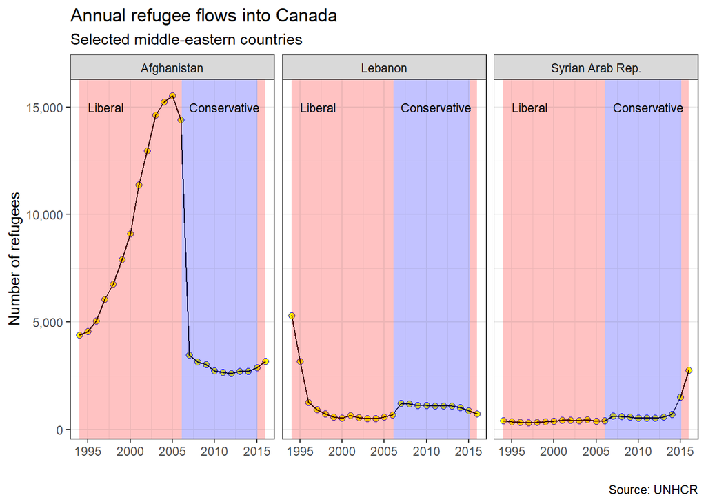

```r
ggplot(data = new_data_3,
       aes(x=year, y=refugees)) +
  geom_point(colour="blue", shape=21, fill="yellow", size=2) +
  geom_line(colour="black") +
  theme_bw() +
  labs(title = "Annual refugee flows into Canada",
       subtitle = "Selected middle-eastern countries",
       caption = "Source: UNHCR",
        x="",
       y="Number of refugees") +
  facet_wrap(~origin_country) +
  scale_y_continuous(labels=scales::comma_format()) +
  geom_rect(aes(xmin=1994,xmax=2006.1,ymin=-Inf,ymax=Inf), fill="red", alpha=0.01) +
  geom_rect(aes(xmin=2006.1,xmax=2015.11,ymin=-Inf,ymax=Inf), fill="blue", alpha=0.01) +
  geom_rect(aes(xmin=2015.11,xmax=2016,ymin=-Inf,ymax=Inf), fill="red", alpha=0.01) +
  annotate(geom="text",
           x=1995,y=15000,
           label="Liberal",
           hjust=0,
           size=3) +
  annotate(geom="text",
           x=2007,y=15000,
           label="Conservative",
           hjust=0,
           size=3)
```

## Saving your plot

Once you’ve created the plot you want, you can save it using `ggsave()`. The function is pretty straightforward. You put it right after the code used to create a figure, and tell it what the output file should be called, including the file type (I usually use PNG files, but you can create JPG or other file types too). You can additionally tell it the width and height of the figure (in inches, remember that a piece of paper is 8.5x11". So to save the above, you would type:

```r
ggsave("refugee_figure.png", width=6, height=4)
```

## Other types of plots

We’ve now introduced line-type plots, which are useful for plotting time-series data. However, `ggplot` can produce many different types of plots using different [geoms](https://ggplot2.tidyverse.org/reference/). Here, I illustrate a bar chart, which is useful for plotting categorical data; however, there are also many other types of plots. To make your own plot of a different type, it is useful to start from [example code](http://r-statistics.co/Top50-Ggplot2-Visualizations-MasterList-R-Code.html) of the type of figure you’d like to end up with.

We will make a bar chart starting with the same data set as above. However, we will graph refugee flows from all countries to Canada in 2016, with the height of each bar being the number of refugees into Canada from that country. We will include the top 10 countries plus another bar for other countries. This requires some data manipulation first:

```r
top_10 <- dat %>%
  filter(year == 2016,
         country_or_territory_of_asylum_or_residence == "Canada") %>%
  select(origin_country = country_or_territory_of_origin,
         refugees = refugees_sup_sup) %>%
  arrange(desc(refugees)) %>%
  top_n(n=10)
top_10
```

```
## # A tibble: 10 x 2
##    origin_country   refugees
##    <chr>               <dbl>
##  1 Colombia             8228
##  2 China                7356
##  3 Haiti                6774
##  4 Sri Lanka            4648
##  5 Pakistan             4564
##  6 Mexico               4102
##  7 Nigeria              4068
##  8 Afghanistan          3177
##  9 Somalia              2775
## 10 Syrian Arab Rep.     2757
```

Now we can plot this data:

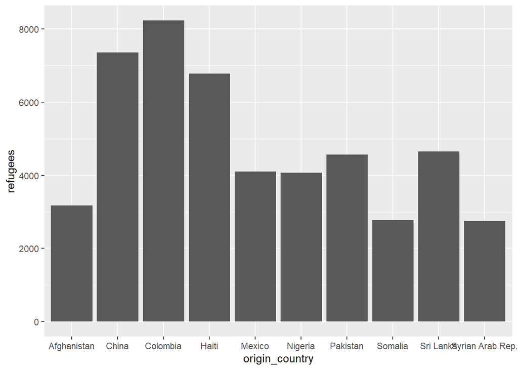

```r
ggplot(data=top_10,
       aes(x=origin_country, y=refugees)) +
  geom_col()
```

Hmm. R has automatically ordered our x axis alphabetically. We can override this automatic ordering by telling `ggplot` to order by the size of refugee flows (or whatever else we want).

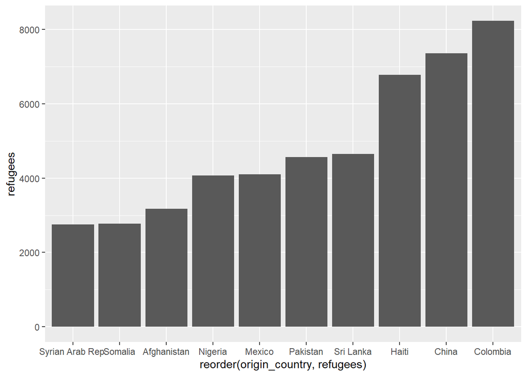

```r
ggplot(data=top_10,
       aes(
         # Here we are reordering origin country by number of refugees
         x=reorder(origin_country, refugees),
         y=refugees)) +
  geom_col()
```

Now we can clean the figure up (adding labels, choosing themes, etc.). One thing to notice is that the country names are a bit squished in the prior figure. We can fix this either by putting them on an angle, or else by flipping the coordinates. I do the latter here.

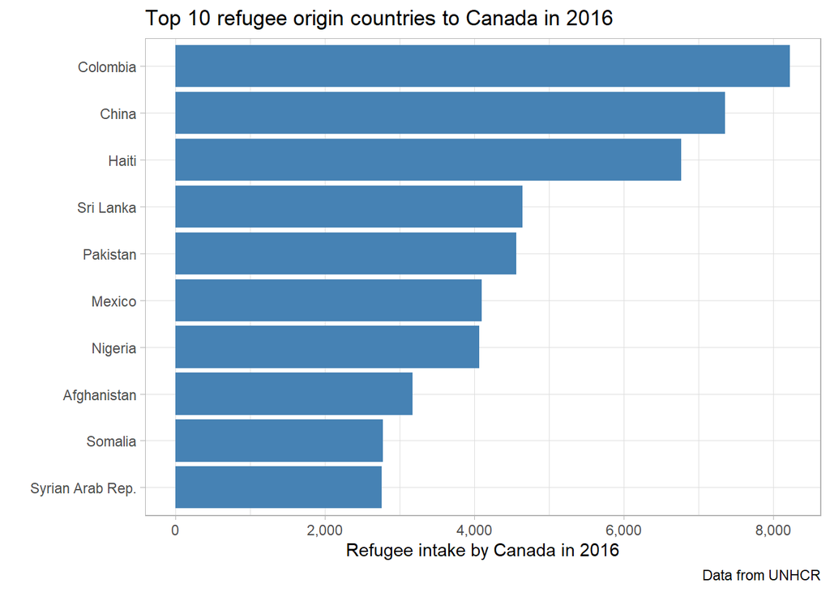

```r
ggplot(data=top_10,
       aes(
         # Here we are reordering origin country by number of refugees
         x=reorder(origin_country, refugees),
         y=refugees)) +
  geom_col(fill="steelblue") +
  # flip the axes
  coord_flip() +
  # labels
  labs(x="",
       y="Refugee intake by Canada in 2016",
       title="Top 10 refugee origin countries to Canada in 2016",
       caption="Data from UNHCR") +
  theme_light() +
  scale_y_continuous(labels=comma_format())
```

[figure not shown]

```r
compare_2016_1996 <- dat %>%
  filter(year %in% c(1996,2016),
         country_or_territory_of_asylum_or_residence == "Canada",
         # Only keep origin countries in the top 10 for 2016
         country_or_territory_of_origin %in% top_10$origin_country) %>%
  select(origin_country = country_or_territory_of_origin,
         year,
         refugees = refugees_sup_sup)

# Now plot the data
ggplot(compare_2016_1996,
       aes(x=reorder(origin_country, refugees), y=refugees, fill=factor(year))) +
  geom_col(position="dodge") +
  labs(x="",
       y="Refugee intake by Canada",
       title="Top 10 refugee origin countries to Canada in 2016",
       subtitle="Comparison with refugee intake a decade earlier",
       caption="Data from UNHCR") +
  theme_light() +
  scale_y_continuous(labels=comma_format()) +
  coord_flip() +
  scale_fill_manual(name="Year of intake",
                    values = c("steelblue", "firebrick"))
```

## Plotting micro-data

The above examples were based on aggregate data – data for all of Canada. Often we will want to plot micro-data (on individuals, for example). We will work with the Labour Force Survey to illustrate the process for visualising micro-data. You can get the latest Labour Force Survey (and codebook) on ODESI and read it into R.

```r
lfs <- read_csv("data/lfs-71M0001-E-2019-february.zip")
```

```
## Multiple files in zip: reading 'lfs-71M0001-E-2019-february_F1.csv'
```

We have data on 100,000 individuals. Let’s try to figure out whether wages differ by gender in the data, and provide a useful plot to summarise. The gender variable is SEX (with 1=male and 2=female) and the wage variable is HRLYEARN. We can try plotting a separate point for each individual in the data. First, though, we eliminate people from the data who don’t report any earnings.

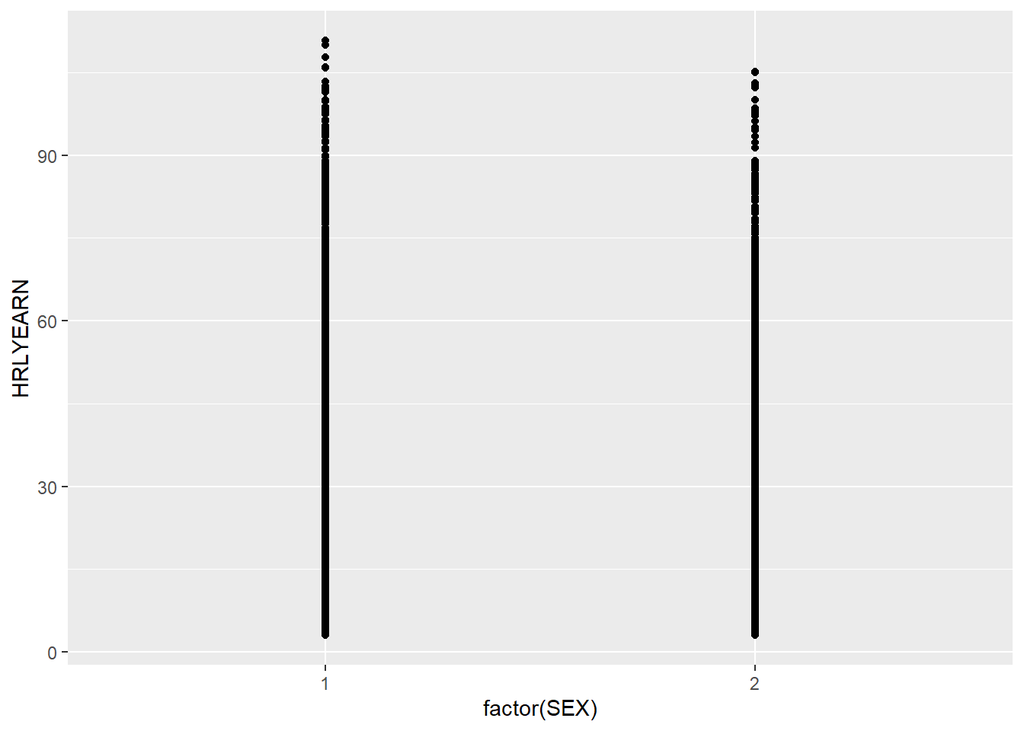

```r
lfs_earn <- lfs %>%
  filter(HRLYEARN > 0)

ggplot(lfs_earn,
       aes(x=factor(SEX), y=HRLYEARN)) +
  geom_point()
```

This figure is ugly and uninformative. It’s ugly because the labels aren’t effective – the reader would need to know that 1 means male and 2 means female and the units for HRLYEARN. It’s uninformative because there are lots of dots plotted on top of one another, so the dots just come out as a blur. This is a common problem with micro-data, and there are good [solutions](https://ggplot2.tidyverse.org/reference/geom_point.html#overplotting) to fixing it. Here, I show a couple of potential plots that can improve on the one we started with.

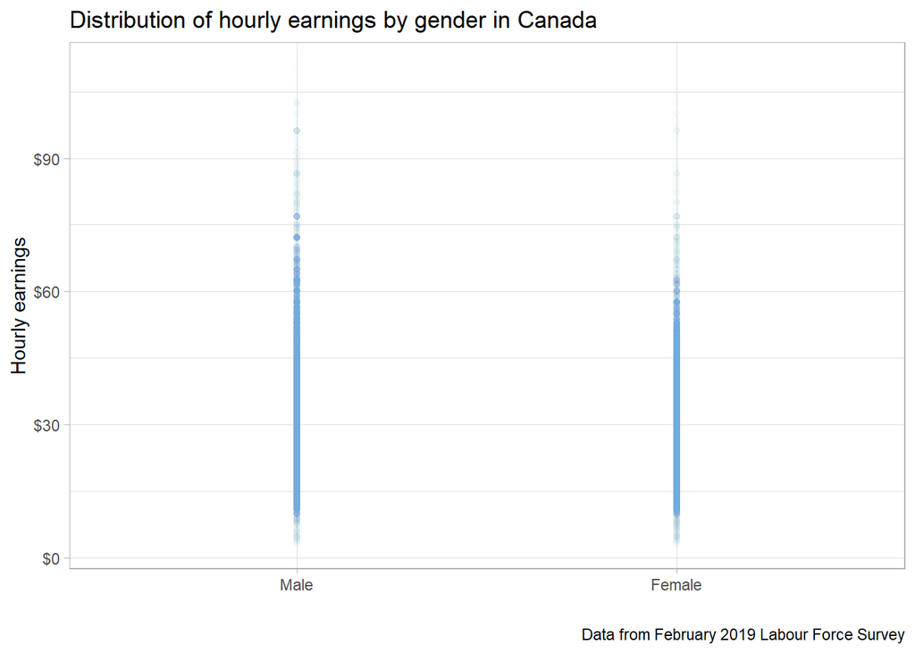

```r
# First, let's put a male and female label on
lfs_earn <- lfs_earn %>%
  # Tell R SEX is a factor variable and label the levels of the variable
  mutate(gender = factor(SEX, levels=c(1,2), labels=c("Male","Female")))

ggplot(lfs_earn,
       aes(x=gender, y=HRLYEARN)) +
  geom_point(colour="steelblue",
             # set the opacity lower so that when plots are on top of one another they appear darker
             alpha = 0.01) +
  theme_light() +
  labs(
    x="",
    y="Hourly earnings",
    title="Distribution of hourly earnings by gender in Canada",
    caption="Data from February 2019 Labour Force Survey"
  ) +
  # Format the scale with dollars
  scale_y_continuous(labels=dollar_format())
```

This is an improvement, but still not perfect. We can use the `jitter` function to scatter the points about a little, so there is less overlap. We can also overlay with a boxplot. This is now a more informative figure.

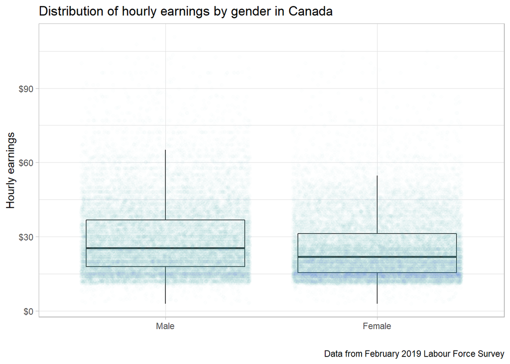

```r
ggplot(lfs_earn,
       aes(x=gender, y=HRLYEARN)) +
  geom_boxplot(outlier.shape = NA) +
  geom_point(colour="steelblue",
             # set the opacity lower so that when plots are on top of one another they appear darker
             alpha = 0.01,
             position="jitter") +
  theme_light() +
  labs(
    x="",
    y="Hourly earnings",
    title="Distribution of hourly earnings by gender in Canada",
    caption="Data from February 2019 Labour Force Survey"
  ) +
  # Format the scale with dollars
  scale_y_continuous(labels=dollar_format())
```

Exercises: * Graph the average male and female hourly wage for individuals from 25 to 34 years old with a Bachelor’s degree or above who are employed and at work, according to their occupation (NOC_10). (Try yourself before looking at the answer below).

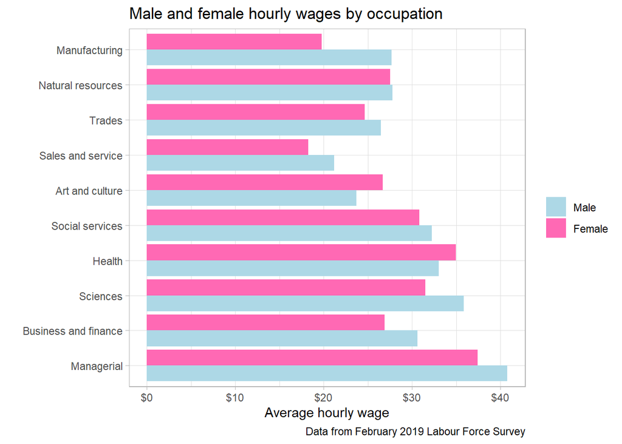

```r
# First filter the data set as described
plot_1_data <- lfs %>%
  filter(
    # Only keep individuals 25 to 34 (see codebook)
    AGE_12 %in% c(3,4),
    # Only keep individuals with bachelor degree or above
    EDUC %in% c(5,6),
    # Only keep individuals employed and at work
    LFSSTAT == 1,
    # Only keep people with observed wages
    !is.na(HRLYEARN)
  ) %>%
  # Create more informative gender category
  mutate(gender = factor(SEX, labels = c("Male", "Female")),
         # Create more informative occupations category
         occupation = factor(NOC_10,
                             labels=c("Managerial",
                                      "Business and finance",
                                      "Sciences",
                                      "Health",
                                      "Social services",
                                      "Art and culture",
                                      "Sales and service",
                                      "Trades",
                                      "Natural resources",
                                      "Manufacturing"))) %>%
  # group by occupation and gender
  group_by(occupation, gender) %>%
  # Find mean by group
  summarise(average_wage = mean(HRLYEARN))

# Now plot
ggplot(plot_1_data,
       aes(x=occupation, y=average_wage, fill=gender)) +
  geom_col(position="dodge") +
  scale_fill_manual(name="", values=c("Male" = "lightblue",
                                      "Female" = "hotpink")) +
  coord_flip() +
  scale_y_continuous(labels=dollar_format()) +
  labs(y="Average hourly wage",
       x="",
       title="Male and female hourly wages by occupation",
       caption="Data from February 2019 Labour Force Survey") +
  theme_light()
```

- Graph the average wage according to the amount of eduction the responded has, for males between 35 and 44. Facet the graph by province. (Try yourself).